# Aprendizaje reforzado

En el aprendizaje reforzado, el modelo no aprende de un conjunto de datos fijo, sino que aprende de un entorno dinámico, además de que no se tiene entrenamiento supervisado.

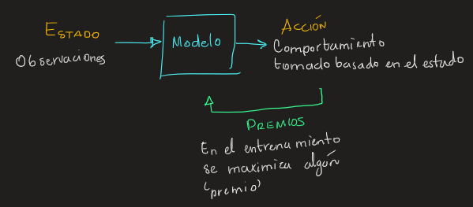

- **Agente:** Es la parte que realiza la acción, por ejemplo, puede ser un dron.
- **Entorno:** Es el mundo en donde el agente existe y toma accinoes, con el cual interactúa.
- **Acciones:** Son la forma en la que el agente interactúa con el entorno. Al conjunto de acciones se le denota como $A$.
- **Observaciones**: El ambiente retorna observaciones al agente en la forma de *estados*.
- **Premio:** Es una retroalimentación con la que se mide el éxito de las acciones del agente.

## Premio

Podemos formular el premio total como la suma de todos los premios a partir de un tiempo $t$. Una forma de amortiguar los premios es agregar un factor $\gamma$ donde $0 \leq \gamma \leq 1$, que hace que los premios a largo plazo sean menores y por lo tanto premia más por aquellos en el momento $t$.

$$ R_t = \sum_{i=t} ^ \infty \gamma^i r_i $$

### Función Q

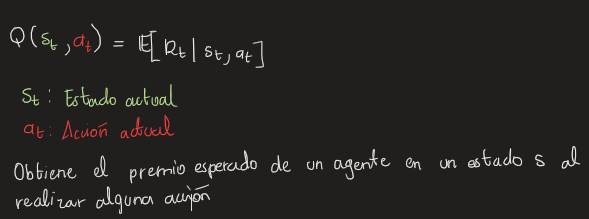

Para tomar las mejores acciones en un estado determinado se utilizan **políticas $\pi(s)$**, que proporciona cuál es la mejor acción a tomar dado un estado determinado. Esta función debe maximizar las recompensas futuras. Entonces podemos definir la política como:

$$ \pi(s) = \underset{a}{\text{argmax}}Q(s,a) $$

Se tienen dos tipos de aprendizaje:

- Encontrar $Q$.
- Encontrar $\pi$.

### Deep Q Learning

- Una forma de aprender la función $Q$ es definiendo una red neuronal que toma como entradas el estado y la acción, dando como salida el valor de $Q$.
- Otra forma de realizar el aprendizaje es dar como entrada el estado, y como salida todos los posibles valores de Q relacionados a cada una de las acciones. Esta es una mejor forma de resolver el problema, ya que tenemos que ejecutar una sola vez nuestra red para poder obtener el mejor valor de la acción.

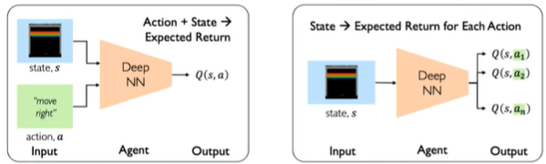

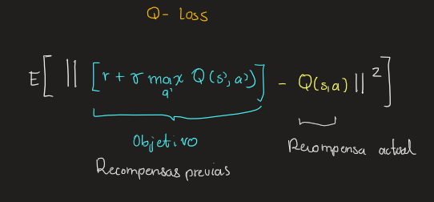

Para entrenar nuestra red neuronal (que tendrá la función Q) se utiliza la función de pérdida Q.

### Desventajas

- Únicamente podemos utilizar este modelo cuando nuestras acciones son discretas (número finito de ellas).
- No se puede aprender de procesos estocásticos, ya que las políticas son determinísticas.

## Policy gradient

En este tipo de entrenamiento se optimiza el valor de $\pi(s)$, en este caso no se optimiza la recompensa, sino que se trata de obtener la mejor acción, analizando la probabilidad de cuál es la mejor acción en un estado en concreto.

### Ventajas

- Podemos tener un espacio continuo de acciones.
- Podemos manejar eventos estocásticos.

En este tipo de entrenamiento, se intenta optimizar los parámetros que describen a la distribución de probabilidad.

### Entrenamiento

1. Inicializar el agente.
2. Ejecutar la política hasta que termine.
3. Guardar los estados, acciones y recompensas tomadas durante la primera ejecución.
4. Reducir las probabilidades de las acciones que resultaron en recompensas menores.
5. Incrementar las probabilidades de las acciones que resultaron en recompensas mayores.

La función de costo de este tipo de entrenamiento tienen la siguiente expresión:

$$ loss = -\log P(a_t|s_t)R_t $$

La primer parte nos dice la probabilidad de realizar una acción dado un estado. La segunda parte, $R_t$ nos dice la recompensa de la acción actual. Entonces para poder realizar los pasos 4 y 5, utilizamos gradiente descendiente con esta función de costo:

$$ w' = w + \nabla \log P(a_t|s_t)R_t $$